# Coursera - Practical Machine Learning - Week4 Project - Markdown File

Shahbaz Alam

30th March, 2021

# Coursera-PracticalMachineLearning - Week 4 Project Assignment

**Note:** The full-report is available in this file, after the introduction of the project

The compiled HTML file is available here: https://github.com/Choton-1/practical_ML_predictionAssignment

## Background

Using devices such as Jawbone Up, Nike FuelBand, and Fitbit it is now possible to collect a large amount of data about personal activity relatively inexpensively. These type of devices are part of the quantified self movement - a group of enthusiasts who take measurements about themselves regularly to improve their health, to find patterns in their behavior, or because they are tech geeks. One thing that people regularly do is quantify how much of a particular activity they do, but they rarely quantify how well they do it. In this project, your goal will be to use data from accelerometers on the belt, forearm, arm, and dumbell of 6 participants. They were asked to perform barbell lifts correctly and incorrectly in 5 different ways. More information is available from the website here: http://groupware.les.inf.puc-rio.br/har (see the section on the Weight Lifting Exercise Dataset).

## DataSet

The training data for this project are available here:  
https://d396qusza40orc.cloudfront.net/predmachlearn/pml-training.csv

The test data are available here:  
https://d396qusza40orc.cloudfront.net/predmachlearn/pml-testing.csv

The data for this project come from this source: http://groupware.les.inf.puc-rio.br/har.  
If you use the document you create for this class for any purpose please cite them as they have been very generous in allowing their data to be used for this kind of assignment.

## Peer Review Portion

Your submission for the Peer Review portion should consist of a link to a Github repo with your R markdown and compiled HTML file describing your analysis. Please constrain the text of the writeup to < 2000 words and the number of figures to be less than 5. It will make it easier for the graders if you submit a repo with a gh-pages branch so the HTML page can be viewed online (and you always want to make it easy on graders.

## Reproducibility

Due to security concerns with the exchange of R code, your code will not be run during the evaluation by your classmates. Please be sure that if they download the repo, they will be able to view the compiled HTML version of your analysis.

## Full Report describing how I built the model, how I used cross-validation, accuracy and errors, and choices I made

### STEP 1 - Loading the R Packages

```r
library(caret)
```

```r
library(rpart)
library(rpart.plot)
library(RColorBrewer)
library(RGtk2)
library(rattle)
library(randomForest)
```

### STEP 2 - Loading the Dataset

Download the data files from the Internet and load them into two data frames. We ended up with a training dataset and a 20 observations testing dataset that will be submitted to Coursera.

```r
UrlTrain <- "http://d396qusza40orc.cloudfront.net/predmachlearn/pml-training.csv"
UrlTest  <- "http://d396qusza40orc.cloudfront.net/predmachlearn/pml-testing.csv"

current_path <- rstudioapi::getSourceEditorContext()$path
setwd(dirname(current_path))

dt_training<-read.csv("./data/pml-training.csv", na.strings = c("NA", "#DIV/0!", ""))
dt_testing<-read.csv("./data/pml-testing.csv", na.strings = c("NA", "#DIV/0!", ""))


dim(dt_training)
```

```
## [1] 19622   160
```

```r
dim(dt_testing)
```

```
## [1]  20 160
```

```r
# head(dt_training)
```

### STEP 3 - Cleaning the Data

Remove all columns that contains NA and remove features that are not in the testing dataset. The features containing NA are the variance, mean and standard devition (SD) within each window for each feature. Since the testing dataset has no time-dependence, these values are useless and can be disregarded. Also remove the first 7 features as they are related to the time-series or are not numeric.

List of features remaining:

```r
features <- names(dt_testing[,colSums(is.na(dt_testing)) == 0])[8:59]
features
```

```
##  [1] "roll_belt"            "pitch_belt"           "yaw_belt"
##  [4] "total_accel_belt"     "gyros_belt_x"         "gyros_belt_y"
##  [7] "gyros_belt_z"         "accel_belt_x"         "accel_belt_y"
## [10] "accel_belt_z"         "magnet_belt_x"        "magnet_belt_y"
## [13] "magnet_belt_z"        "roll_arm"             "pitch_arm"
## [16] "yaw_arm"              "total_accel_arm"      "gyros_arm_x"
## [19] "gyros_arm_y"          "gyros_arm_z"          "accel_arm_x"
## [22] "accel_arm_y"          "accel_arm_z"          "magnet_arm_x"
## [25] "magnet_arm_y"         "magnet_arm_z"         "roll_dumbbell"
## [28] "pitch_dumbbell"       "yaw_dumbbell"         "total_accel_dumbbell"
## [31] "gyros_dumbbell_x"     "gyros_dumbbell_y"     "gyros_dumbbell_z"
## [34] "accel_dumbbell_x"     "accel_dumbbell_y"     "accel_dumbbell_z"
## [37] "magnet_dumbbell_x"    "magnet_dumbbell_y"    "magnet_dumbbell_z"
## [40] "roll_forearm"         "pitch_forearm"        "yaw_forearm"
## [43] "total_accel_forearm"  "gyros_forearm_x"      "gyros_forearm_y"
## [46] "gyros_forearm_z"      "accel_forearm_x"      "accel_forearm_y"
## [49] "accel_forearm_z"      "magnet_forearm_x"     "magnet_forearm_y"
## [52] "magnet_forearm_z"
```

Only use features used in testing cases:

```r
dt_training <- dt_training[,c(features,"classe")]
dt_testing <- dt_testing[,c(features,"problem_id")]

dim(dt_training)
```

```
## [1] 19622    53
```

```r
dim(dt_testing)
```

```
## [1] 20 53
```

### STEP 4 - Partitioning the Dataset (into training & cross-validation sets)

Setting the seed for reproducibility

```r
set.seed(5656)
```

The objective is to get training, cross-validation, and testing sets. I split the training data into a training data set (60% of the total cases) and a testing data set - or cross-validation (40% of the total cases). It will help estimate the out of sample error.

```r
inTrain <- createDataPartition(dt_training$classe, p=0.6, list=FALSE)
training <- dt_training[inTrain,]
crossval <- dt_training[-inTrain,]

dim(training)
```

```
## [1] 11776    53
```

```r
dim(crossval)
```

```
## [1] 7846   53
```

### STEP 5 - Building and comparing the Models

#### 1st Model - Decision Tree

First, I will try using Decision Tree. The accuracy may not be high.

Build the model:

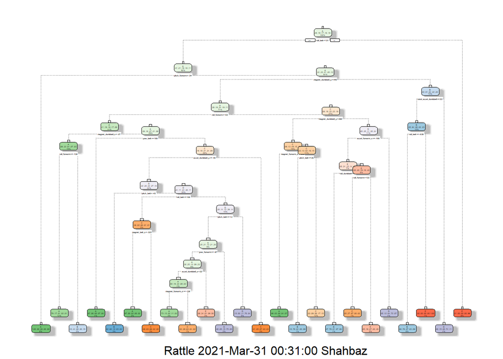

```r
modFitDT <- rpart(classe ~ ., data = training, method="class")
rattle::fancyRpartPlot(modFitDT)
```

Prediction:

```r
set.seed(5656)
prediction <- predict(modFitDT, crossval, type = "class")
crossval$classe <- factor(crossval$classe, levels = levels(prediction))
confusionMatrix(prediction, crossval$classe)
```

```
## Confusion Matrix and Statistics
##
##           Reference
## Prediction    A    B    C    D    E
##          A 1971  234   20   74   21
##          B   70  841   71   97  104
##          C   70  175 1149  196  174
##          D   80  122   86  808   84
##          E   41  146   42  111 1059
##
## Overall Statistics
##
##                Accuracy : 0.7428
##                  95% CI : (0.733, 0.7524)
##     No Information Rate : 0.2845
##     P-Value [Acc > NIR] : < 2.2e-16
##
##                   Kappa : 0.6745
##
##  Mcnemar's Test P-Value : < 2.2e-16
##
## Statistics by Class:
##
##                      Class: A Class: B Class: C Class: D Class: E
## Sensitivity            0.8831   0.5540   0.8399   0.6283   0.7344
## Specificity            0.9378   0.9460   0.9051   0.9433   0.9469
## Pos Pred Value         0.8496   0.7109   0.6514   0.6847   0.7570
## Neg Pred Value         0.9528   0.8984   0.9640   0.9283   0.9406
## Prevalence             0.2845   0.1935   0.1744   0.1639   0.1838
## Detection Rate         0.2512   0.1072   0.1464   0.1030   0.1350
## Detection Prevalence   0.2957   0.1508   0.2248   0.1504   0.1783
## Balanced Accuracy      0.9104   0.7500   0.8725   0.7858   0.8407
```

#### 2nd Model - Random Forest

Using random forest, the out of sample error should be small. The error will be estimated using the 40% testing sample.

Build the model:

```r
set.seed(5656)
training$classe <- factor(training$classe, levels = levels(prediction))
modFitRF <- randomForest(classe ~ ., data = training, ntree = 1000)
```

Prediction:

```r
prediction <- predict(modFitRF, crossval, type = "class")

confusionMatrix(prediction, crossval$classe)
```

```
## Confusion Matrix and Statistics
##
##           Reference
## Prediction    A    B    C    D    E
##          A 2231    9    0    0    0
##          B    0 1504   10    0    0
##          C    0    5 1357   15    0
##          D    0    0    1 1271    7
##          E    1    0    0    0 1435
##
## Overall Statistics
##
##                Accuracy : 0.9939
##                  95% CI : (0.9919, 0.9955)
##     No Information Rate : 0.2845
##     P-Value [Acc > NIR] : < 2.2e-16
##
##                   Kappa : 0.9923
##
##  Mcnemar's Test P-Value : NA
##
## Statistics by Class:
##
##                      Class: A Class: B Class: C Class: D Class: E
## Sensitivity            0.9996   0.9908   0.9920   0.9883   0.9951
## Specificity            0.9984   0.9984   0.9969   0.9988   0.9998
## Pos Pred Value         0.9960   0.9934   0.9855   0.9937   0.9993
## Neg Pred Value         0.9998   0.9978   0.9983   0.9977   0.9989
## Prevalence             0.2845   0.1935   0.1744   0.1639   0.1838
## Detection Rate         0.2843   0.1917   0.1730   0.1620   0.1829
## Detection Prevalence   0.2855   0.1930   0.1755   0.1630   0.1830
## Balanced Accuracy      0.9990   0.9946   0.9944   0.9936   0.9975
```

**As can be seen from the confusion matrix the Random Forest model is very accurate, about 99.3%.**

### STEP 5 - Predicting on the Testing Data (pml-testing.csv)

#### Decision Tree Prediction

```r
predictionDT <- predict(modFitDT, dt_testing, type = "class")
predictionDT
```

```
##  1  2  3  4  5  6  7  8  9 10 11 12 13 14 15 16 17 18 19 20
##  B  A  C  D  A  C  D  A  A  A  C  E  C  A  E  E  A  B  B  B
## Levels: A B C D E
```

#### Random Forest Prediction

```r
predictionRF <- predict(modFitRF, dt_testing, type = "class")
predictionRF
```

```
##  1  2  3  4  5  6  7  8  9 10 11 12 13 14 15 16 17 18 19 20
##  B  A  B  A  A  E  D  B  A  A  B  C  B  A  E  E  A  B  B  B
## Levels: A B C D E
```